# Finding Low Stiffness Logs

JH

9/14/2015

If we were searching for the lowest stiffness logs how much worse would our selection be if just velocity and volume were used compared to velocity, volume, weight and heartwood %?

For logs with exceptional (high or low) heartwood contents, the relationship between greeen log SWV and average dry (or green) board MOE can be expected to be poorer than for those with a typical heartwood content.

# LS16 - Hyne

Get the data. Use trimmed hitman for log SWV and USNR for log volume.

```r
library(RODBC)
ch = odbcConnect('Hyne',uid='sa',pwd="password12")
L = sqlQuery(ch, "select nboards, SWV, volume vol, weight/volume den, volumeheart/volume hw, Egcorrected_avg Egreen, Edhitman_avg Edry from tmp_logquality q")
```

Drop logs with low representation or missing values.

```r
L = na.omit(L[L$nboards/L$vol>=10,])
```

Build models for green and dry AvgBoardMOE based on two types of model:

1. reduced (red) - using SWV and volume only
2. full (ful) - using SWV, volume, log green density and heartwood fraction.

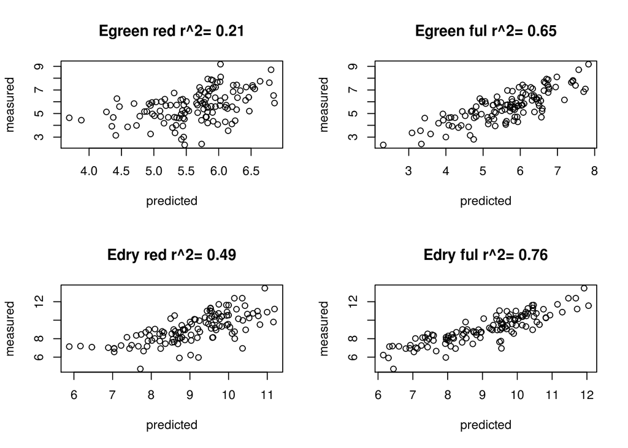

```r
models = list()
model.predictors = list(red=c('SWV','vol'), ful=c('SWV','vol','den','hw'))
par(mfrow=c(2,2))
for (meas in c('Egreen','Edry')) {
  for (model in c('red','ful')) {
    f = formula(paste(meas,"~",paste(model.predictors[[model]], collapse="+")))
    m = lm(f, L)
    models[[paste(meas,model,sep=".")]] = m
    plot(predict(m),L[,meas],xlab="predicted",ylab="measured",main=paste(meas,model,"r^2=",round(100*summary(m)$r.squared)/100))
  }
}
```

For increasing predicted cutoffs, plot the % of logs that would be selected by both types of model.

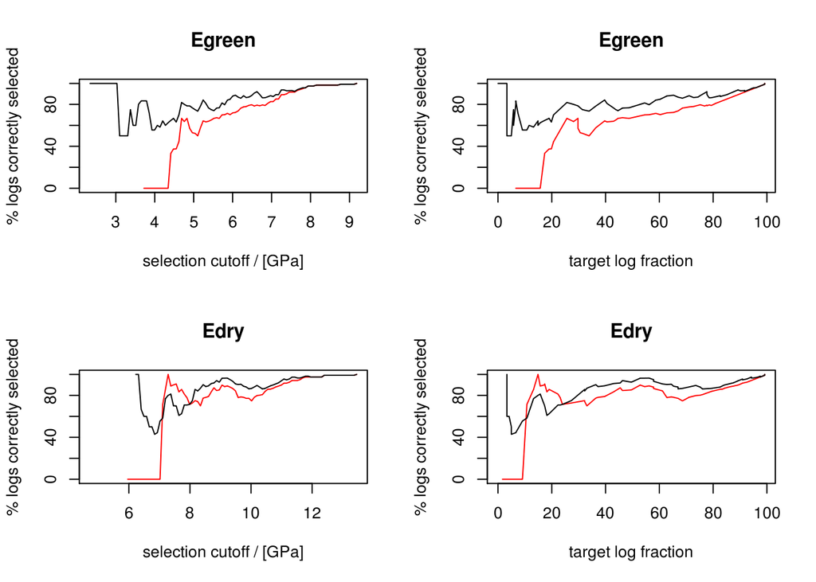

```r
par(mfrow=c(2,2))
for (meas in c('Egreen','Edry')) {
    pred.red = predict(models[[paste(meas,'red',sep=".")]])
    pred.ful = predict(models[[paste(meas,'ful',sep=".")]])
    breaks = seq(min(L[,meas]),max(L[,meas]),length.out=100)
    frac.ful = breaks*NA
    frac.red = breaks*NA
    log.frac = breaks*NA
    for (ibreak in 1:length(breaks)) {
      b = breaks[ibreak]
      sel.ful = names(pred.ful[pred.ful<=b])
      sel.red = names(pred.red[pred.red<=b])
      frac.ful[ibreak] = sum(L[sel.ful,meas]<=b)/length(sel.ful)
      frac.red[ibreak] = sum(L[sel.red,meas]<=b)/length(sel.red)
      log.frac[ibreak] = sum(L[,meas]<b)/nrow(L)
    }
    plot(breaks, frac.red*100, main=meas, type="l", xlab="selection cutoff / [GPa]", ylab="% logs correctly selected", ylim=c(0,100), col="red")
    lines(breaks, frac.ful*100, main=meas, type="l", col="black")
    plot(log.frac*100, frac.red*100, main=meas, type="l", xlab="target log fraction", ylab="% logs correctly selected", ylim=c(0,100), col="red")
    lines(log.frac*100, frac.ful*100, main=meas, type="l", col="black")
}
```

Black lines represent the full model (swv, volume, green density and heartwood fraction). Red lines represent the reduced model (swv and volume only).

Instead of using an absolute set point, what if we base the setpoint on the model predictions?

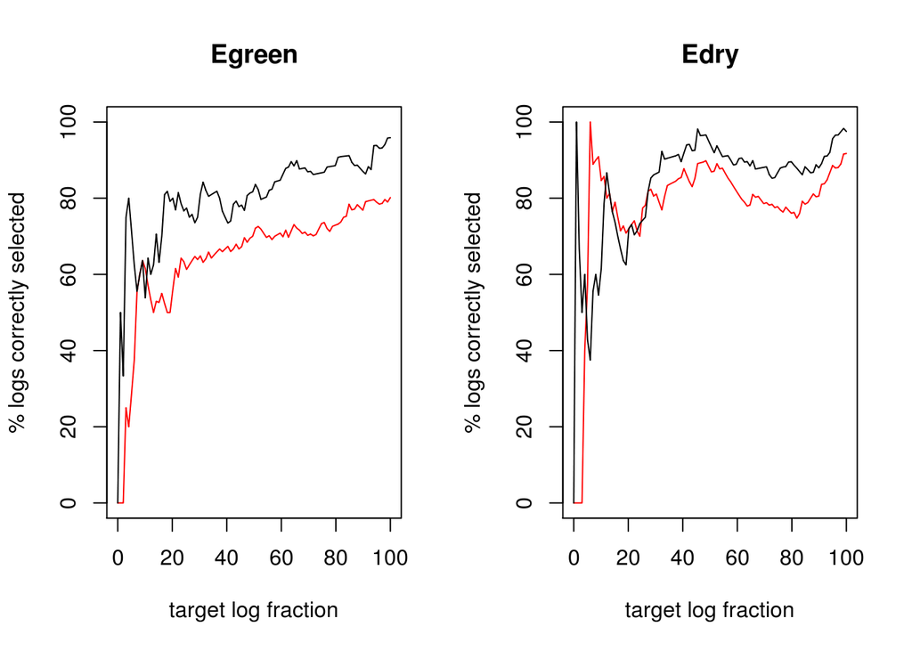

```r
par(mfrow=c(1,2))
for (meas in c('Egreen','Edry')) {
    pred.red = predict(models[[paste(meas,'red',sep=".")]])
    pred.ful = predict(models[[paste(meas,'ful',sep=".")]])
    log.frac = seq(0,1,length.out=100)
    frac.ful = breaks*NA
    frac.red = breaks*NA
    for (ifrac in 1:length(log.frac)) {
      b.ful = quantile(pred.ful, log.frac[ifrac])
      b.red = quantile(pred.red, log.frac[ifrac])
      sel.ful = names(pred.ful[pred.ful<=b.ful])
      sel.red = names(pred.red[pred.red<=b.red])
      frac.ful[ifrac] = sum(L[sel.ful,meas]<=b.ful)/length(sel.ful)
      frac.red[ifrac] = sum(L[sel.red,meas]<=b.red)/length(sel.red)
    }
    plot(log.frac*100, frac.red*100, main=meas, type="l", xlab="target log fraction", ylab="% logs correctly selected", ylim=c(0,100), col="red")
    lines(log.frac*100, frac.ful*100, main=meas, type="l", col="black")
}
```

# LS15 - KPP

There are no log weights or green board MOE’s in the KPP dataset. Log volume is estimated based on SED.

```r
ch = odbcConnect('LS15')
L=sqlQuery(ch,"select nboards,  swvhitman SWV, volsed vol, heartVolFrac hw, moebavg Edry from logs_logVlumber")
L = na.omit(L[L$nboards/L$vol>=25,])
```

Build models for dry AvgBoardMOE based on two types of model:

1. reduced (red) - using SWV and volume only
2. full (ful) - using SWV, volume and heartwood fraction.

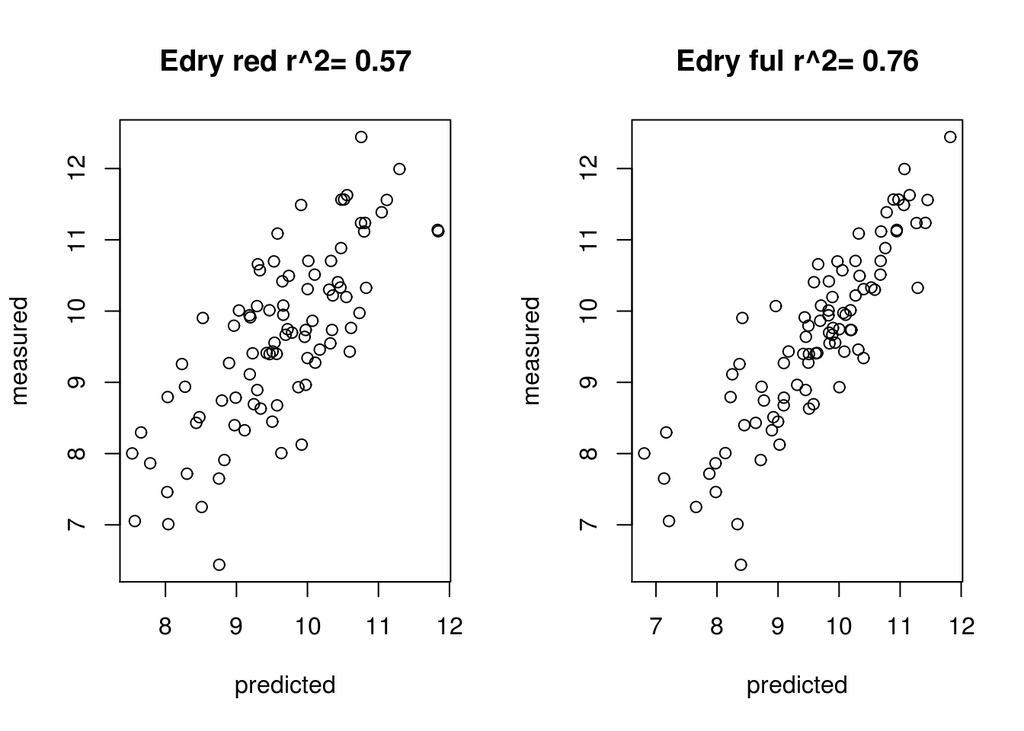

```r
models = list()
model.predictors = list(red=c('SWV','vol'), ful=c('SWV','vol','hw'))
par(mfrow=c(1,2))
for (model in c('red','ful')) {
    f = formula(paste(meas,"~",paste(model.predictors[[model]], collapse="+")))
    m = lm(f, L)
    models[[paste(meas,model,sep=".")]] = m
    plot(predict(m),L[,meas],xlab="predicted",ylab="measured",main=paste(meas,model,"r^2=",round(100*summary(m)$r.squared)/100))
  }
```

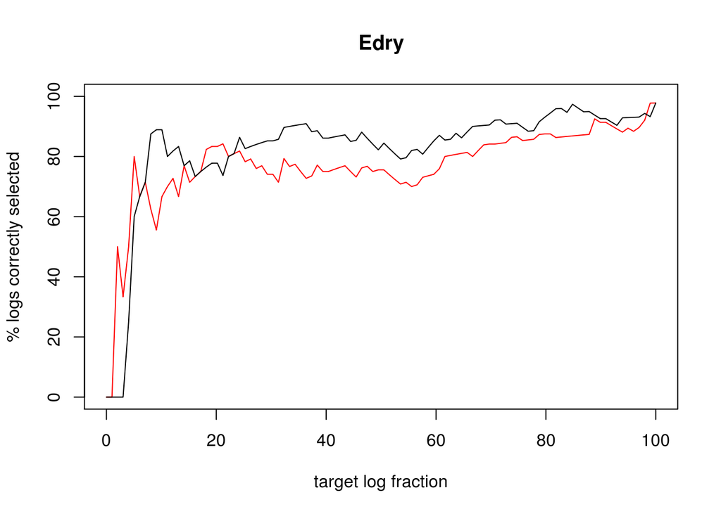

```r
par(mfrow=c(1,1))
for (meas in c('Edry')) {
    pred.red = predict(models[[paste(meas,'red',sep=".")]])
    pred.ful = predict(models[[paste(meas,'ful',sep=".")]])
    log.frac = seq(0,1,length.out=100)
    frac.ful = breaks*NA
    frac.red = breaks*NA
    for (ifrac in 1:length(log.frac)) {
      b.ful = quantile(pred.ful, log.frac[ifrac])
      b.red = quantile(pred.red, log.frac[ifrac])
      sel.ful = names(pred.ful[pred.ful<=b.ful])
      sel.red = names(pred.red[pred.red<=b.red])
      frac.ful[ifrac] = sum(L[sel.ful,meas]<=b.ful)/length(sel.ful)
      frac.red[ifrac] = sum(L[sel.red,meas]<=b.red)/length(sel.red)
    }
    plot(log.frac*100, frac.red*100, main=meas, type="l", xlab="target log fraction", ylab="% logs correctly selected", ylim=c(0,100), col="red")
    lines(log.frac*100, frac.ful*100, main=meas, type="l", col="black")
}
```

Similar to results from Hyne. Reduced model appears to do better finding logs with lowest stiffness out-turn.

# IFS16 - KPP

Neither log weight nor % heartwood available.

# Conclusions

With only 100 logs its hard to tell if what we see here is representative, particularly when the target log fraction is low.

That said, the data we have indicates that selection based on SWV and volume only is not terribly dissimilar to one that includes log weight and heartwood %. Furthermore, selections based on either can be expected to be around 80% correct.